# Barred Sand Bass, Southern California Recreational Fishery

Operating Model Report

Heather Gliniak, California Department of Fish and Wildlife

Sarah Valencia, SeaChange Analytics

May 2021

# Introduction

Barred sand bass (Paralabrax nebulifer) are one of the most common sea basses in the family Serranidae inhabiting southern California coastal waters. Barred sand bass range from Santa Cruz, California to southern Baja California, Mexico, but are more common south of Point Conception (Love and Passarelli 2020). Juvenile barred sand bass are abundant over shallow sandy bottoms in bays and estuaries at depths of 1.5 to 6 meters (m) (5 to 20 feet) (ft) (Mendoza-Carranza and Rosales-Casian 2002). Adults are typically found in deeper water ranging from 20 to 30 m (65 to 100 ft) at the sand/reef interface of natural and artificial reefs (Teesdale et al. 2015) but have been observed at depths up to 183 m (600 ft) (Eschmeyer and Herald 1999).

They are fished on coastal reefs year-round but are most commonly targeted when they form large annual spawning aggregations over sand flats at depths of 10 to 30 m (32.8 to 98.4 ft) (Love et al. 1996a). Popular fishing grounds for barred sand bass in California have historically included spawning aggregation sites such as Silver Strand, Del Mar and San Onofre in San Diego County, Huntington Flats in Orange County, Santa Monica in Los Angeles County and Ventura Flats in northern Ventura County (Jarvis et al. 2010). However, in more recent years these aggregations have have become much smaller or very difficult to find, which has raised concern about the status of the stock. No estimate of depletion exists, but both catches and catch rates have been declining since 2000, and have recently reached their lowest level since 1980, when the modern fishery developed (CDFW 2019). Together with the long history of exploitation of spawning aggregations, this suggests that the stock may be moderately to heavily depleted.

This report describes the parameters used in the base operating model for an MSE of the barred sand bass recreational fishery. Parameter estimates were based on published estimates or CDFW data whenever possible, and expert judgement when no estimates were available. The number of simulations for a final model run (nsim) was set at 250 and fishing was projected 50 years to the future (proyears). The management interval tested was 1 year. The maximum instantaneous fishing mortality rate for an age class (maxF) was set at 0.8, which is the default value in the DLMtool. The number of samples for stochastic MPs (reps) was set at 1, and the percentile of the sample of the management recommendation (pstar) used for each stochastic MP was set at 0.5.

We used custom parameters (cpars) to parameterize time varying retention of barred sand bass due to a variety of size limit changes over the fishery history. The minimum size has changed a number of times. A size limit of 276 mm was first established in 1953. It was increased to 279 mm in 1957, 299 mm in 1958, and to 305 mm in 1959, and it remained there until it was increased to the present size in 2013 to address concerns regarding the status of barred sand bass and kelp bass populations. RecFIN data on size compositions of the catch suggest that a small percentage of sublegal fish are retained each year. Because of this, rather than parameterizing a knife-edged retention curve at the size limit we fit a logistic retention curve to the size composition data from the Private Rental and CPFV fleets for each year of available data (1980 to 2018). We assumed that all fish were able to be retained prior to 1953, and that retention followed the size limits implemented between 1953 and 1959. For the period between 1960 and 1980 we assumed that retention for each year was equal to the estimated retention of 1980. Retention was estimated annually from the data from 1980 on. This generated an array of probability of retention values for each size bin of 10 mm width to be populated in the cpars$RetL slot. This array has dimensions simulations x length bins x years.

# Operating Model

The OM rdata file can be downloaded from here

Download and import into R using `myOM <- readRDS('OM.rdata')`

## Species Information

**Species**: *Paralabrax nebulifer*

**Common Name**: *Barred Sand Bass*

**Management Agency**: CDFW

**Region**: California, USA

**Sponsor**: Resource Legacy Fund

**Latitude**: 34.42083

**Longitude**: -119.69819

## OM Parameters

**OM Name**: Name of the operating model: BSB_CA

**nsim**: The number of simulations: 250

**proyears**: The number of projected years: 50

**interval**: The assessment interval - how often would you like to update the management system? 1

**pstar**: The percentile of the sample of the management recommendation for each method: 0.5

**maxF**: Maximum instantaneous fishing mortality rate that may be simulated for any given age class: 0.8

**reps**: Number of samples of the management recommendation for each method. Note that when this is set to 1, the mean value of the data inputs is used. 1

**Source**: A reference to a website or article from which parameters were taken to define the operating model

# Stock Parameters

### Mortality and age: maxage, R0, M, Msd

**maxage**: The maximum age of individuals that is simulated. There are maxage+1 (recruitment to age-0) age classes in the storage matrices. maxage is the plus group where all age-classes > maxage are grouped, unless option switched off with OM@cpars$plusgroup=0 . Single value. Positive integer.

Specified Value(s): 35

Jarvis et al. (2014) estimated natural mortality to be 0.218 using the Pauly (1980) method. This corresponds to an approximate maximum age of about 21 years. The oldest fish recorded was 24 years old (Love et al. 1996b), however, this observation was from a time when the fishery had experienced considerable fishing pressure for many decades. The maximum age parameter was set to 35, which corresponds to an upper limit for longevity that corresponds to the lower bound on M.

**R0**: Initial number of unfished recruits to age-0. This number is used to scale the size of the population to match catch or data, but does not affect any of the population dynamics unless the OM has been conditioned with data. As a result, for a data-limited fishery any number can be used for R0 . In data-rich stocks R0 may be estimated as part of a stock assessment, but for data limited stocks users can choose either an arbitrary number (say, 1000) or choose a number that produces simulated catches in recent historical years that are similar to real world catch data. Single value. Positive real number.

Specified Value(s): 1e+05

In the absence of a stock assessment, there is currently no estimate for R0. It is used as a scaling parameter in the DLMtool, so the starting number of recruits does not affect the results of the model, and it was set arbitrarily at 100,000.

**M**: The instantaneous rate of natural mortality. For each simulation a single value is drawn from a uniform distribution specified by the upper and lower bounds provided. Uniform distribution lower and upper bounds. Non-negative real numbers.

Specified Value(s): 0.16, 0.22

**Msd**: Inter-annual variation in M expressed as a coefficient of variation of a log-normal distribution. For each simulation a single value is drawn from a uniform distribution specified by the upper and lower bounds provided. If this parameter is positive, yearly M is drawn from a log-normal distribution with a mean specified by log(M) drawn for that simulation and a standard deviation in log space specified by the value of Msd drawn for that simulation. Uniform distribution lower and upper bounds. Non-negative real numbers

Specified Value(s): 0, 0

Not used.

### Natural Mortality Parameters

#### Sampled Parameters

Histograms of simulations of `M`, and `Msd` parameters, with vertical colored lines indicating 3 randomly drawn values used in other plots:

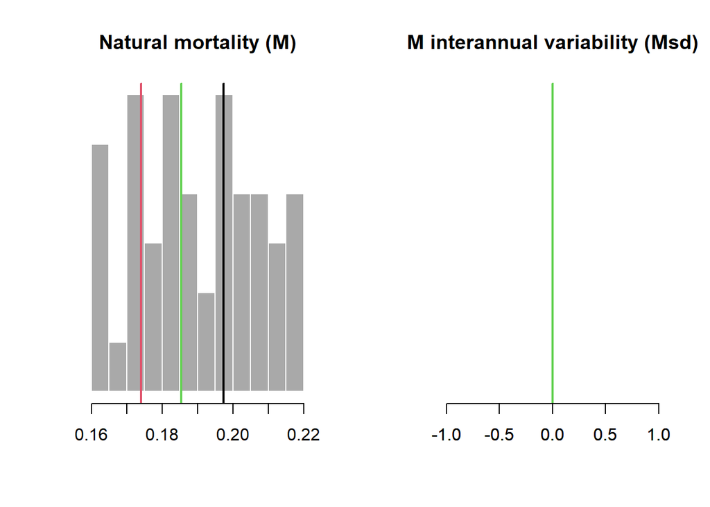

#### Time-Series

The average natural mortality rate by year for adult fish for 3 simulations. The vertical dashed line indicates the end of the historical period:

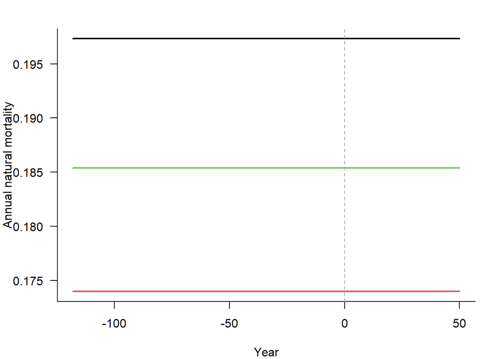

#### M-at-Age

Natural mortality-at-age for 3 simulations in the first historical year, the last historical year (i.e., current year), and the last projected year:

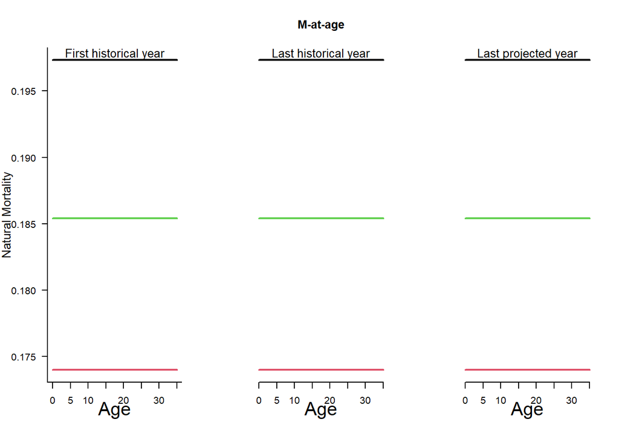

#### M-at-Length

Natural mortality-at-length for 3 simulations in the first historical year, the last historical year (i.e., current year), and the last projected year:

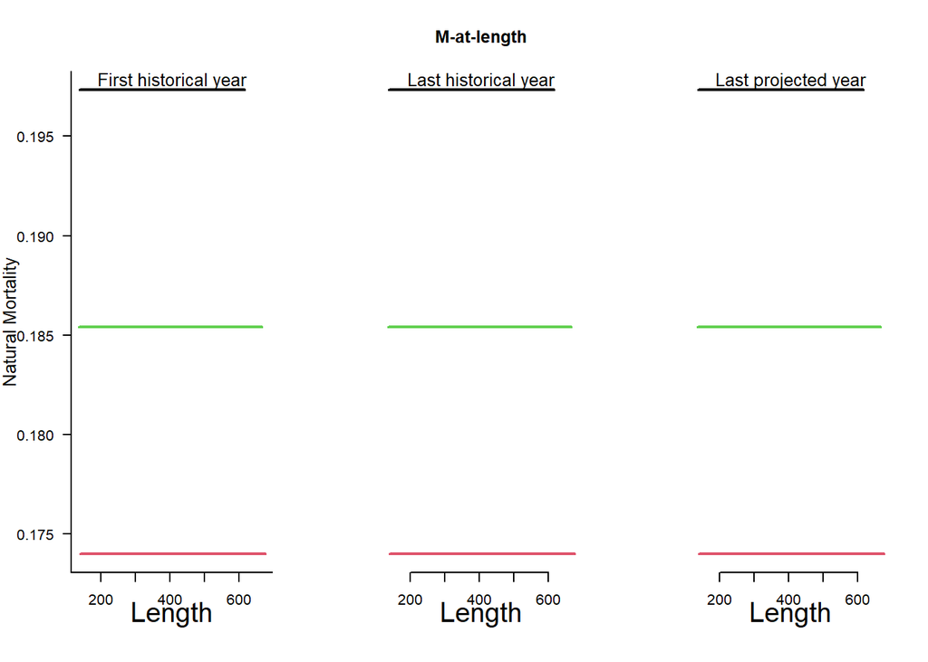

### Recruitment: h, SRrel, Perr, AC

**h**: Steepness of the stock recruit relationship. Steepness governs the proportion of unfished recruits produced when the stock is at 20% of the unfished population size. For each simulation a single value is drawn from a uniform distribution specified by the upper and lower bounds provided. This value is the same in all years of a given simulation. Uniform distribution lower and upper bounds. Values from 1/5 to 1.

Specified Value(s): 0.6, 0.9

Despite the assumption of moderate to high productivity for this species, barred sand bass may be vulnerable to overfishing because they are targeted during spawning aggregations when catch rates are high. There is concern that spawning aggregations becoming much smaller or more difficult to find in more recent years may lead to extremely low reproductive capacity at low population levels because fish can not find others to mate with. This may mean that recovery will take longer for barred sand bass, even under conservative management (Sadovy de Mitcheson 2016). The Beverton-Holt stock recruitment curve does not account for this type of depensation, but we attempted to explore the consequences of reduced productivity through lower steepness values in robustness scenarios.

**SRrel**: Type of stock-recruit relationship. Use 1 to select a Beverton Holt relationship, 2 to select a Ricker relationship. Single value. Integer

Specified Value(s): 1

We assume a Beverton-Holt stock recruitment relationship.

**Perr**: Recruitment process error, which is defined as the standard deviation of the recruitment deviations in log space. For each simulation a single value is drawn from a uniform distribution specified by the upper and lower bounds provided. Uniform distribution lower and upper bounds. Non-negative real numbers.

Specified Value(s): 0.6, 0.9

The average variability in recruitment was estimated from a time series for “rock bass” (barred sand bass, kelp bass and spotted sand bass) based on quarterly plankton tows by California Cooperative Oceanic Fisheries Investigations (CalCOFI) from 1951 to 2015. Rock bass larvae can not be differentiated to the species level, and so this is the best available information on the variability of barred sand bass recruitment. Periods of high and low variability were estimated separately to inform the potential range in variability.

**AC**: Autocorrelation in the recruitment deviations in log space. For each simulation a single value is drawn from a uniform distribution specified by the upper and lower bounds provided, and used to add lag-1 auto-correlation to the log recruitment deviations. Uniform distribution lower and upper bounds. Non-negative real numbers.

Specified Value(s): 0.5, 0.9

The level of autocorrelation in recruitment was also estimated from this CalCOFI data set.

### Recruitment Parameters

#### Sampled Parameters

Histograms of 48 simulations of steepness (`h`), recruitment process error (`Perr`) and auto-correlation (`AC`) for the Beverton-Holt stock-recruitment relationship, with vertical colored lines indicating 3 randomly drawn values used in other plots:

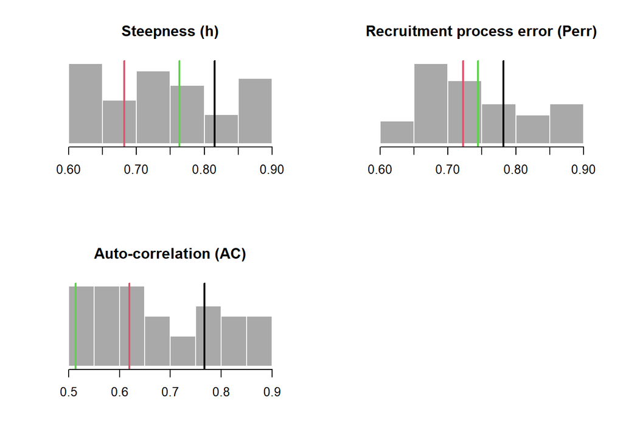

#### Time-Series

Time-series plot showing 3 samples of recruitment deviations for historical and projection years:

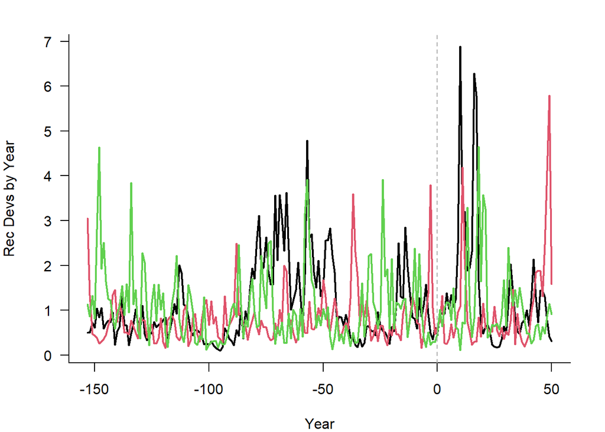

### Growth: Linf, K, t0, LenCV, Ksd, Linfsd

**Linf**: The von Bertalanffy growth parameter Linf, which specifies the average maximum size that would reached by adult fish if they lived indefinitely. For each simulation a single value is drawn from a uniform distribution specified by the upper and lower bounds provided. This value is the same in all years unless Linfsd is a positive number. Uniform distribution lower and upper bounds. Positive real numbers.

Specified Value(s): 595.8, 728.2

Barred sand bass growth is relatively slow with no differences between the sexes. Growth is fast during early years but declines at around age five (Love et al. 1996b). Barred sand bass may reach 670 mm total length (TL) and 6.0 kilogram (kg). The growth parameters used in this model were based on Love et al. 1996b +/- 10%. A recent study by CDFW to update growth parameters estimated a smaller Linf due to a lack of samples of large/old individuals. It is unknown whether this change suggests a change in growth rates over time or the impacts of selective fishing pressure.

**K**: The von Bertalanffy growth parameter k, which specifies the average rate of growth. For each simulation a single value is drawn from a uniform distribution specified by the upper and lower bounds provided. This value is the same in all years unless Ksd is a positive number. Uniform distribution lower and upper bounds. Positive real numbers.

Specified Value(s): 0.07, 0.09

**t0**: The von Bertalanffy growth parameter t0, which specifies the theoretical age at a size 0. For each simulation a single value is drawn from a uniform distribution specified by the upper and lower bounds provided. Uniform distribution lower and upper bounds. Non-positive real numbers.

Specified Value(s): -2.89, -2.37

**LenCV**: The coefficient of variation (defined as the standard deviation divided by mean) of the length-at-age. For each simulation a single value is drawn from a uniform distribution specified by the upper and lower bounds provided to specify the distribution of observed length-at-age, and the CV of this distribution is constant for all age classes (i.e, standard deviation increases proportionally with the mean). Uniform distribution lower and upper bounds. Positive real numbers.

Specified Value(s): 0.05, 0.15

Based on the observed variability in the length at age presented in Love et al. 1996b we modeled a CV between 5 and 15%.

**Ksd**: Inter-annual variation in K. For each simulation a single value is drawn from a uniform distribution specified by the upper and lower bounds provided. If this parameter has a positive value, yearly K is drawn from a log-normal distribution with a mean specified by the value of K drawn for that simulation and a standard deviation (in log space) specified by the value of Ksd drawn for that simulation. Uniform distribution lower and upper bounds. Non-negative real numbers.

Specified Value(s): 0, 0

Not used

**Linfsd**: Inter-annual variation in Linf. For each simulation a single value is drawn from a uniform distribution specified by the upper and lower bounds provided. If this parameter has a positive value, yearly Linf is drawn from a log-normal distribution with a mean specified by the value of Linf drawn for that simulation and a standard deviation (in log space) specified by the value of Linfsd drawn for that simulation. Uniform distribution lower and upper bounds. Non-negative real numbers.

Specified Value(s): 0, 0

Not used.

### Growth Parameters

#### Sampled Parameters

Histograms of simulations of von Bertalanffy growth parameters `Linf`, `K`, and `t0`, and inter-annual variability in Linf and K (`Linfsd` and `Ksd`), with vertical colored lines indicating 3 randomly drawn values used in other plots:

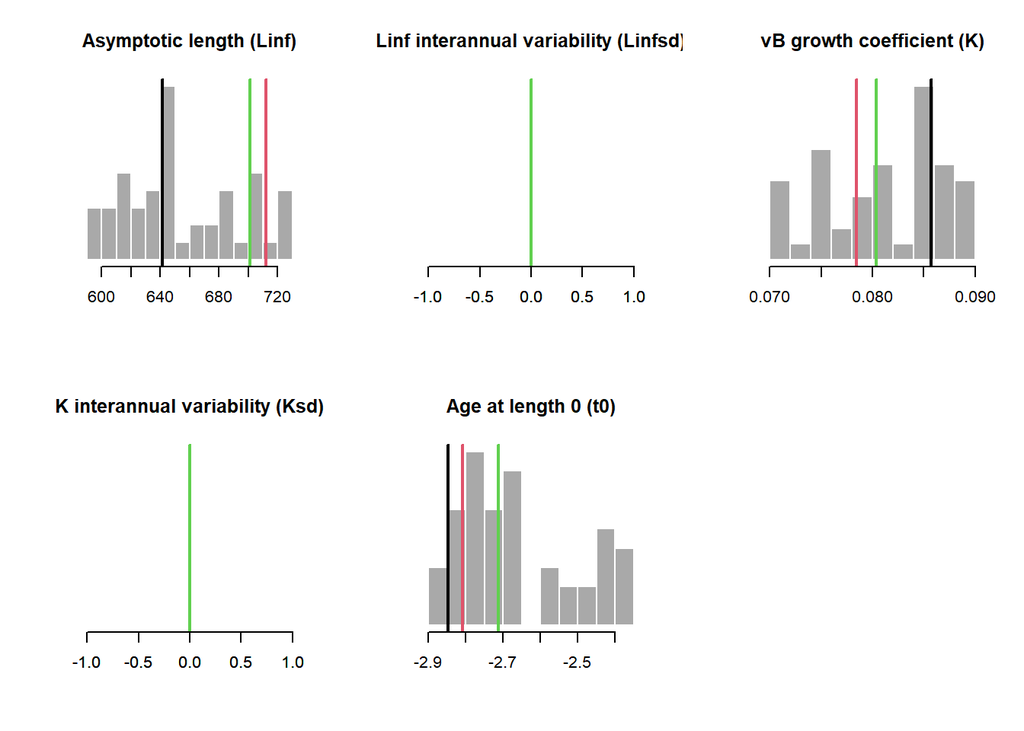

#### Time-Series

The Linf and K parameters in each year for 3 simulations. The vertical dashed line indicates the end of the historical period:

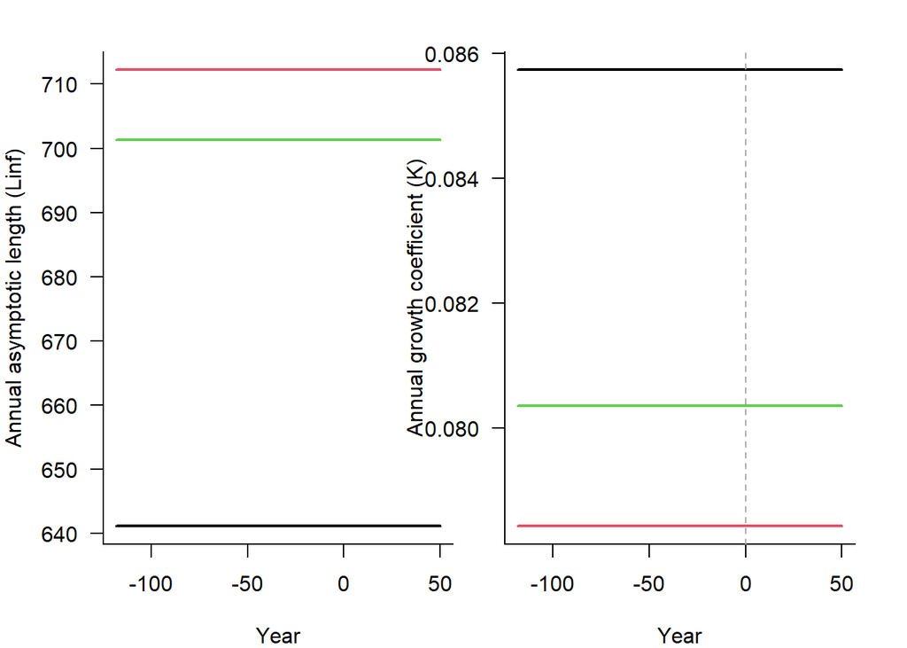

#### Growth Curves

Sampled length-at-age curves for 3 simulations in the first historical year, the last historical year, and the last projection year.

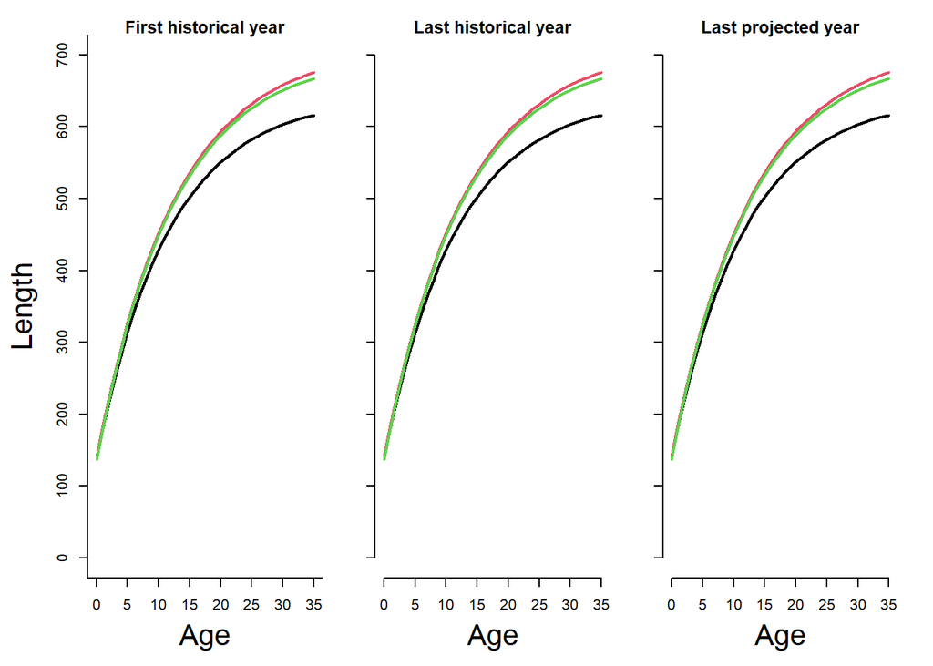

### Maturity: L50, L50_95

**L50**: Length at 50% maturity. For each simulation a single value is drawn from a uniform distribution specified by the upper and lower bounds provided. The L50 and L50_95 parameters are converted to ages using the growth parameters provided and used to construct a logistic curve to determine the proportion of the population that is mature in each age class. Uniform distribution lower and upper bounds. Positive real numbers.

Specified Value(s): 219, 239

Barred sand bass mature at a relatively small size and young age compared to other large reef fishes in California. An estimated 50% of male barred sand bass reach maturity by 219 mm, between 2-4 yr old, and 50% of females reach maturity by 239 mm, between 2 to 5 yr old (Love et al. 1996b). The difference in size at maturity between the sexes is reflected in the upper and lower range modeled.

**L50_95**: Difference in lengths between 50% and 95% maturity. For each simulation a single value is drawn from a uniform distribution specified by the upper and lower bounds provided. The value drawn is then added to the length at 50% maturity to determine the length at 95% maturity. This parameterization is used instead of specifying the size at 95 percent maturity to avoid situations where the value drawn for the size at 95% maturity is smaller than that at 50% maturity. The L50 and L50_95 parameters are converted to ages using the growth parameters provided and used to construct a logistic curve to determine the proportion of the population that is mature in each age class. Uniform distribution lower and upper bounds. Positive real numbers.

Specified Value(s): 20, 40

All males are mature by 260 mm and all females by 270 mm (Love et al. 1996b). Therefore, we modeled an L95 parameter that is 20-40mm larger than the L50 parameter drawn. Note that this is different than in the demo phase of this project, where the L95 was 10-15mm larger than the L50 parameter, which would lead to a more rapid maturation.

### Maturity Parameters

#### Sampled Parameters

Histograms of simulations of `L50` (length at 50% maturity), and `L95` (length at 95% maturity), with vertical colored lines indicating 3 randomly drawn values used in other plots:

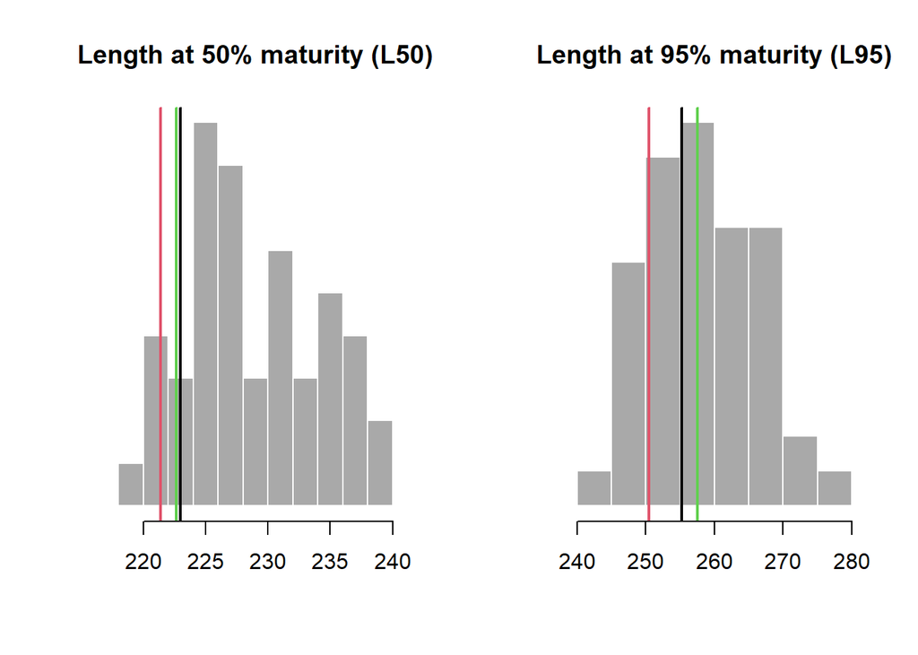

#### Maturity at Age and Length

Maturity-at-age and -length for 3 simulations in the first historical year, the last historical year (i.e., current year), and the last projected year:

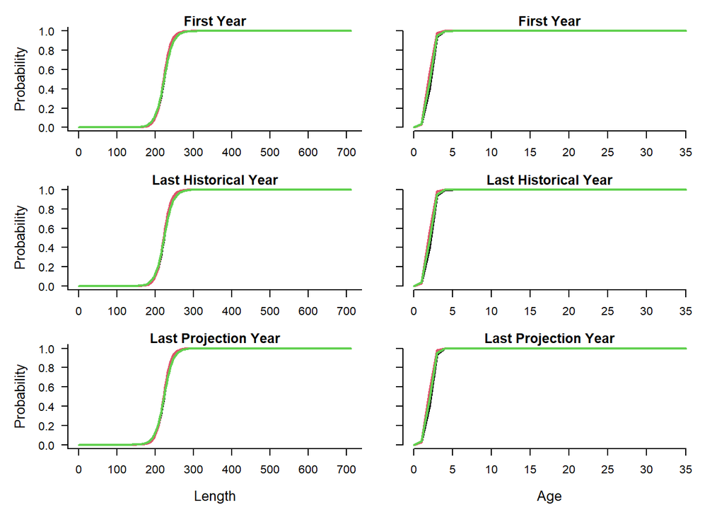

### Stock depletion and Discard Mortality: D, Fdisc

**D**: Estimated current level of stock depletion, which is defined as the current spawning stock biomass divided by the unfished spawning stock biomass. For each simulation a single value is drawn from a uniform distribution specified by the upper and lower bounds provided. This parameter is used during model initialization to select a series of yearly historical recruitment values and fishing mortality rates that, based on the information provided, could have resulted in the specified depletion level in the simulated last historical year. Uniform distribution lower and upper bounds. Positive real numbers (typically < 1)

Specified Value(s): 0.05, 0.25

Abundance estimates from both fishery-dependent and fishery-independent sources indicate that, as of 2017, the population of barred sand bass has declined and is severely depressed (Erisman et al. 2011; Bellquist et al. 2017). Barred sand bass landings have been at their lowest level since 1980, and CPUE has declined since 2000. Annual estimates of relative abundance from fishery independent surveys indicate that adult abundance has remained low since the mid-2000s. This drop in both CPUE and landings is attributed to prolonged overfishing of barred sand bass spawning aggregations combined with poor recruitment during the cool water regime in the early 2000s (Erisman et al. 2011). Spawning aggregations have become much smaller or very difficult to find. However, examination of size distributions suggest that there are still moderate sized fish. Because of all these data we assumed that the stock is between 5 and 25% of unfished levels.

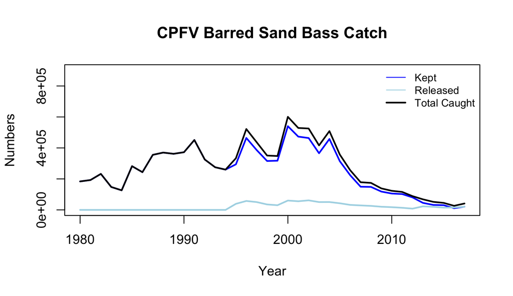

Barred Sand Bass Catch from the CPFV Fleet since 1980

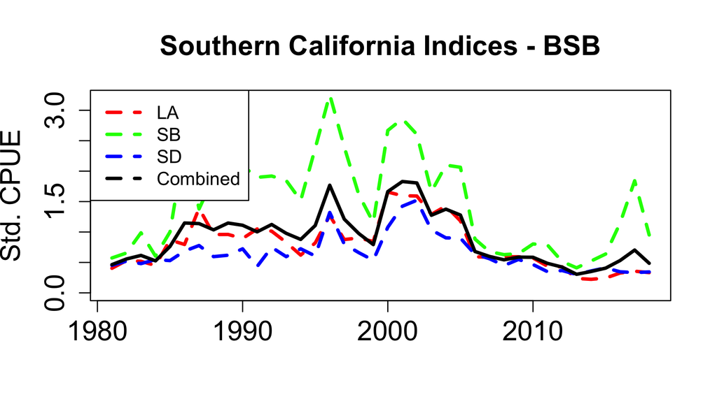

Barred Sand Bass Standardized CPUE from the CPFV Fleet since 1980

**Fdisc**: The instantaneous discard mortality rate the stock experiences when fished using the gear type specified in the corresponding fleet object and discarded. For each simulation a single value is drawn from a uniform distribution specified by the upper and lower bounds provided. Uniform distribution lower and upper bounds. Non-negative real numbers.

Specified Value(s): 0.01, 0.03

Discard mortality results from a combination of sources including fishing-related trauma and predation by California sea lions, sea birds, harbor seals and other fish. The initial post-release mortality of barred sand bass is estimated at 0.92% and short-term (10 days) mortality is estimated at 3.1% for all three bass species combined (Semmens and Parnell 2014). However, recently collected data by CDFW staff suggested that up to 27% of sampled barred sand bass exhibited signs of barotrauma upon release. It is not known whether these barotrauma symptoms contribute to post-release mortality, but higher levels of discard mortality were explored in robustness testing.

### Depletion and Discard Mortality

#### Sampled Parameters

Histograms of simulations of depletion (spawning biomass in the last historical year over average unfished spawning biomass; `D`) and the fraction of discarded fish that are killed by fishing mortality (`Fdisc`), with vertical colored lines indicating 3 randomly drawn values.

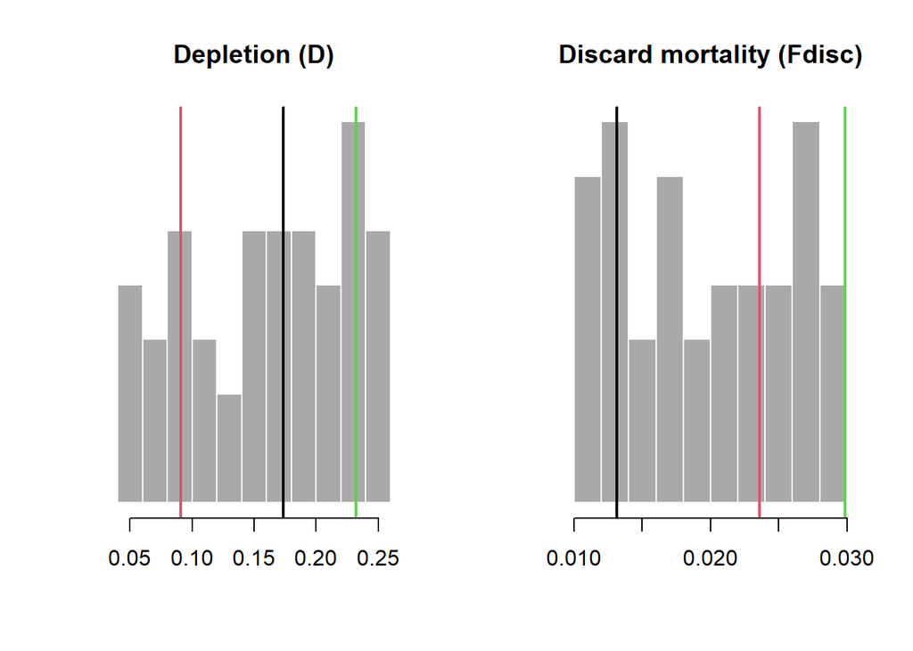

### Length-weight conversion parameters: a, b

**a**: The alpha parameter in allometric length-weight relationship. Single value. Weight parameters are used to determine catch-at-age and population-at-age from the number of individuals in each age class and the length of each individual, which is drawn from a normal distribution determined by the Linf , K , t0 , and LenCV parameters. As a result, they function as a way to scale between numbers at age and biomass, and are not stochastic parameters. Single value. Positive real number.

Specified Value(s): 0

The relationship between weight (in g) and length (in cm) were estimated by Williams et al. (2013) to be a = 0.0000289 and and b=2.95 for barred sand bass. The alpha parameter was converted in order to model weight of the population in metric tons.

**b**: The beta parameter in allometric length-weight relationship. Single value. Weight parameters are used to determine catch-at-age and population-at-age from the number of individuals in each age class and the length of each individual, which is drawn from a normal distribution determine by the Linf , K , t0 , and LenCV parameters. As a result, they function as a way to scale between numbers at age and biomass, and are not stochastic parameters. Single value. Positive real number.

Specified Value(s): 2.95

### Spatial distribution and movement: Size_area_1, Frac_area_1, Prob_staying

**Size_area_1**: The size of area 1 relative to area 2. The fraction of the unfished biomass in area 1. Please specify numbers between 0 and 1. For each simulation a single value is drawn from a uniform distribution specified by the upper and lower bounds provided. For example, if Size_area_1 is 0.2, then 20% of the total area is allocated to area 1. Fishing can occur in both areas, or can be turned off in one area to simulate the effects of a no take marine reserve. Uniform distribution lower and upper bounds. Positive real numbers.

Specified Value(s): 0.5, 0.5

**Frac_area_1**: The fraction of the unfished biomass in area 1. Please specify numbers between 0 and 1. For each simulation a single value is drawn from a uniform distribution specified by the upper and lower bounds provided. For example, if Frac_area_1 is 0.5, then 50% of the unfished biomass is allocated to area 1, regardless of the size of area 1 (i.e, size and fraction in each area determine the density of fish, which may impact fishing spatial targeting). In each time step recruits are allocated to each area based on the proportion specified in Frac_area_1. Uniform distribution lower and upper bounds. Positive real numbers.

Specified Value(s): 0.5, 0.5

**Prob_staying**: The probability of individuals in area 1 remaining in area 1 over the course of one year. Please specify numbers between 0 and 1. For each simulation a single value is drawn from a uniform distribution specified by the upper and lower bounds provided. For example, in an area with a Prob_staying value of 0.95 each fish has a 95% probability of staying in that area in each time step, and a 5% probability of moving to the other area. Uniform distribution lower and upper bounds. Positive fraction.

Specified Value(s): 0.2, 0.3

### Spatial & Movement

#### Sampled Parameters

Histograms of 48 simulations of size of area 1 (`Size_area_1`), fraction of unfished biomass in area 1 (`Frac_area_1`), and the probability of staying in area 1 in a year (`Frac_area_1`), with vertical colored lines indicating 3 randomly drawn values used in other plots:

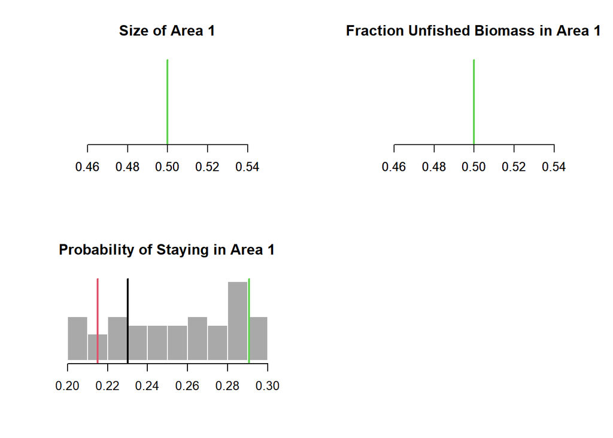

# Fleet Parameters

Barred sand bass has been fished in California since the late 1800s. Commercial landings were first recorded in 1916. The commercial fishery was closed in 1953, and for this reason this model focuses only on the recreational fleet.

### Historical years of fishing, spatial targeting: nyears, Spat_targ

**nyears**: The number of years for the historical simulation. Single value. For example, if the simulated population is assumed to be unfished in 1975 and this is the year you want to start your historical simulations, and the most recent year for which there is data available is 2019, then nyears equals 45.

Specified Value(s): 119

We assume fishing began in 1900, and so the historical period modeled is 119 years (1900-2018).

**Spat_targ**: Distribution of fishing in relation to vulnerable biomass (VB) across areas. The distribution of fishing effort is proportional to VB^Spat_targ. Upper and lower bounds of a uniform distribution. For each simulation a single value is drawn from a uniform distribution specified by the upper and lower bounds provided. This parameter allows the user to model either avoidance or spatial targeting behavior by the fleet. If the parameter value is 1, fishing effort is allocated across areas in proportion to the population density of that area. Values below 1 simulate an avoidance behavior and values above 1 simulate a targeting behavior.

Specified Value(s): 1, 1

### Trend in historical fishing effort (exploitation rate), interannual variability in fishing effort: EffYears, EffLower, EffUpper, Esd

**EffYears**: Vector indicating the historical years where there is information available to infer the relative fishing effort expended.This vector is specified in terms of the position of the year in the vector rather than the calendar year. For example, say our simulation starts with an unfished stock in 1975,and the current year (the last year for which there is data available) is 2019. Then there are 45 historical years simulated, and EffYears should include numbers between 1 and 45. Note that there may not be information available for every historical year, especially for data poor fisheries. In these situations, the EffYears vector should include only the positions of the years for which there is information, and the vector may be shorter than the total number of simulated historical years (nyears).

Barred sand bass have played an important role in the recreational fishing industry in southern California since the 1980s, but prior to that the available data suggests that catches were relatively low. There are three data sets available with which to estimate historical fishing effort: 1) historical catch and effort data from the CPFV fleet between 1936 and 1979, which includes catches specified as “rock bass”, a category that can include barred sand bass, kelp bass, or spotted sand bass, as well as by individual species 2) historical commercial landings, which were outlawed in 1953, and 3) the modern Marine Log System (MLS) database, which records catch and effort for all CPFV trips since 1980.

Prior to 1945 there are very few barred sand bass landings recorded in the historical CPFV database, though they may have been recorded under the rock bass category. Some small recreational charter boat trips began targeting barred sand bass in the early 20th century but the CPFV fleet did not fully develop until after 1929 (Young 1969). In the 1930s and 1940s barred sand bass were not a popular sport fish, but as more anglers entered the fishery they rose in popularity because they are so easy to catch with hook and line during spawning aggregations. They were also targeted prior to 1953 by the commercial fishery. Beginning in the late 1940s there is catch data for a small amount of barred sand bass, but the majority of catches were composed of kelp bass, and so it is assumed that the “rock bass” category is primarily kelp bass landings. Based on these data and the additional historical information available it is assumed that fishing effort was low in the early part of the century, dropped to zero during WWII, resumed at a low level after the war, and increased through the 1950s, 60s, and 70s. This is supported by information from CDFW internal reports from the 1960s, which suggest that catches of barred sand bass caught by recreational anglers increased dramatically in response to warm conditions in the mid 1960s. In the late 1970s barred sand bass catch and effort may have increased from strong recruitment during rising ocean temperatures (Stephens et al. 1994) and the ease of catching legal adults during spawning aggregations (Ally et al. 1991).

Beginning in 1980, there is more comprehensive data with which to assess fishing effort. The modern CPFV logbook database records every CPFV trip in California, and currently CDFW considers any trip that encountered at least one barred sand bass to be targeting the species. In keeping with this approach we calculated the relative fishing effort as the total number of trips that caught one or more barred sand bass, scaled to the maximum during this time series, and +/- 20%. However, this method likely provides an underestimate of the true level of relative fishing effort because it does not count those trips that were targeting barred sand bass but did not catch one, something that is more likely to happen as the stock size declines. Because many of the MPs tested in forward simulations adjust fishing effort relative to the fishing effort in the last historical year, this method may negatively bias both current and future fishing effort.

Therefore we explored a number of different methods to determine which trips were likely to have been targeting barred sand bass based on their timing and location. It was decided that twilight trips, which we defined as fishing trips that left the dock between 5 and 7pm and which returned to the dock between 8 pm and 2 am, are trips that have traditionally targeted spawning aggregations of barred sand bass over nearshore sandy flats. Departure and return time has only been collected since 1995, so this information was only available for the latter half of the time series. However, this method of defining fishing effort resulted in less decline in fishing effort in recent years. It was decided to use this method of defining fishing effort (including the number of twilight fishing trips after 1995, scaled to the maximum, +/- 20%) as a robustness scenario.

**EffLower**: Lower bound on relative fishing effort corresponding to EffYears. EffLower must be a vector that is the same length as EffYears describing how fishing effort has changed over time. Information on relative fishing effort can be entered in any units provided they are consistent across the entire vector because the data provided will be scaled to 1 (divided by the maximum number provided).

**EffUpper**: Upper bound on relative fishing effort corresponding to EffYears. EffUpper must be a vector that is the same length as EffYears describing how fishing effort has changed over time. Information on relative fishing effort can be entered in any units provided they are consistent across the entire vector because the data provided will be scaled to 1 (divided by the maximum number provided).

| EffYears | EffLower | EffUpper |
| --- | --- | --- |
| 1900 | 0.000 | 0.000 |
| 1910 | 0.050 | 0.050 |
| 1934 | 0.050 | 0.050 |
| 1939 | 0.000 | 0.000 |
| 1946 | 0.000 | 0.000 |
| 1949 | 0.350 | 0.650 |
| 1964 | 0.650 | 0.750 |
| 1974 | 0.549 | 0.851 |
| 1975 | 0.617 | 0.783 |
| 1976 | 0.467 | 0.701 |
| 1977 | 0.467 | 0.701 |
| 1979 | 0.467 | 0.701 |
| 1980 | 0.469 | 0.703 |
| 1981 | 0.502 | 0.753 |
| 1982 | 0.531 | 0.796 |
| 1983 | 0.470 | 0.705 |
| 1984 | 0.457 | 0.685 |
| 1985 | 0.548 | 0.821 |
| 1986 | 0.578 | 0.867 |
| 1987 | 0.579 | 0.868 |
| 1988 | 0.605 | 0.907 |
| 1989 | 0.557 | 0.835 |
| 1990 | 0.623 | 0.934 |
| 1991 | 0.648 | 0.971 |
| 1992 | 0.597 | 0.896 |
| 1993 | 0.595 | 0.892 |
| 1994 | 0.559 | 0.838 |
| 1995 | 0.566 | 0.848 |
| 1996 | 0.708 | 1.060 |
| 1997 | 0.799 | 1.200 |
| 1998 | 0.800 | 1.200 |
| 1999 | 0.644 | 0.966 |
| 2000 | 0.739 | 1.110 |
| 2001 | 0.747 | 1.120 |
| 2002 | 0.666 | 0.999 |
| 2003 | 0.618 | 0.928 |
| 2004 | 0.629 | 0.944 |
| 2005 | 0.554 | 0.831 |
| 2006 | 0.523 | 0.785 |
| 2007 | 0.502 | 0.753 |
| 2008 | 0.455 | 0.683 |
| 2009 | 0.419 | 0.628 |
| 2010 | 0.360 | 0.540 |
| 2011 | 0.369 | 0.554 |
| 2012 | 0.384 | 0.576 |
| 2013 | 0.284 | 0.426 |
| 2014 | 0.312 | 0.467 |
| 2015 | 0.266 | 0.399 |
| 2016 | 0.180 | 0.271 |
| 2017 | 0.212 | 0.318 |
| 2018 | 0.212 | 0.318 |

**Esd**: Additional inter-annual variability in fishing mortality rate. For each historical simulation a single value is drawn from a uniform distribution specified by the upper and lower bounds provided. If this parameter has a positive (non-zero) value, the yearly fishing mortality rate is drawn from a log-normal distribution with a standard deviation (in log space) specified by the value of Esd drawn for that simulation. This parameter applies only to historical projections.

Specified Value(s): 0.1, 0.4

An interannual variability in effort of 10-40% was assumed. These are the default values from the DLMtool, and are used to assist in fitting historical fishing mortality trends to the effort time series provided in EffUpper and EffLower.

### Historical Effort

#### Sampled Parameters

Histograms of 48 simulations of inter-annual variability in historical fishing mortality (`Esd`), with vertical colored lines indicating 3 randomly drawn values used in the time-series plot:

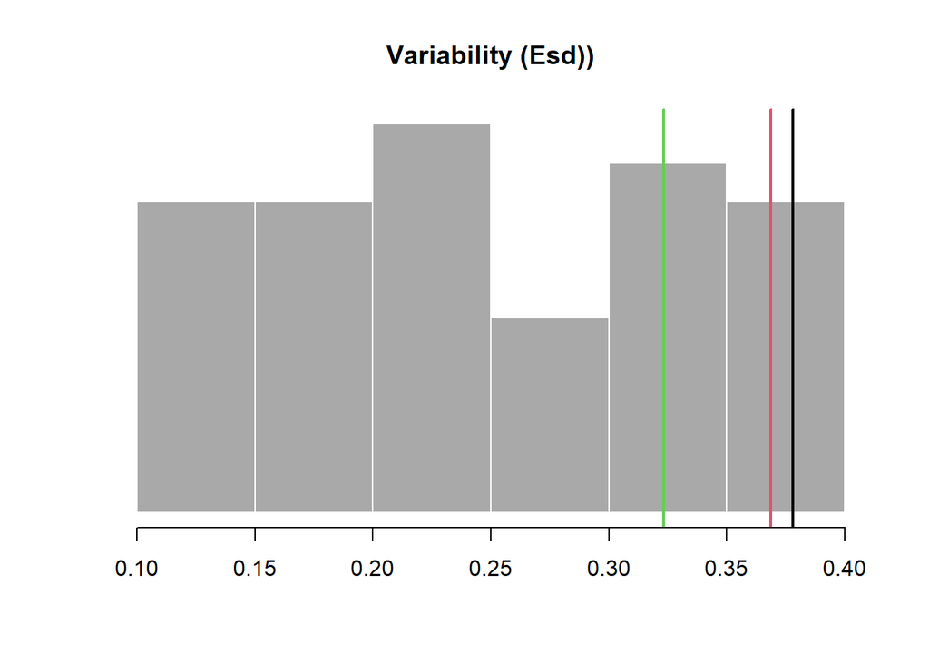

#### Time-Series

Time-series plot showing 3 trends in historical fishing mortality (`OM@EffUpper` and `OM@EffLower` or `OM@cpars$Find`):

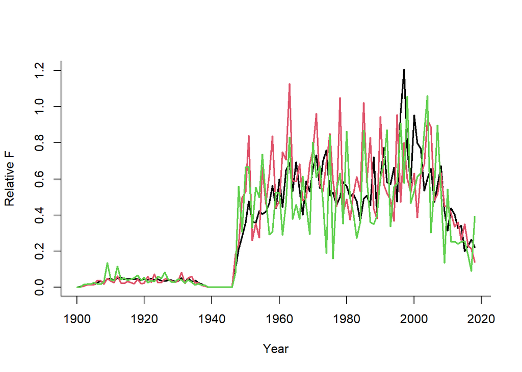

### Annual increase in catchability, interannual variability in catchability: qinc, qcv

**qinc**: Mean temporal trend in catchability (also though of as the efficiency of fishing gear) parameter, expressed as a percentage change in catchability (q) per year. For each simulation a single value is drawn from a uniform distribution specified by the upper and lower bounds provided. Positive numbers indicate an increase and negative numbers indicate a decrease. q then changes by this amount for in each year of the simulation This parameter applies only to forward projections.

Specified Value(s): -0.1, 0.1

In the base model it was assumed that catchability (which can also be inferred as a trend in fishing effort in future projections) would stay relatively stable in future years. However, it is possible that as the population of California continues to grow there may be a long term increase in recreational fishing effort. We estimated the average trend in the total number of CPFV fishing trips as averaging 0.3% per year between 1980 and 2018, and this rate of increase in fishing effort +/- 50% was tested as an uncertainty scenario.

**qcv**: Inter-annual variability in catchability expressed as a coefficient of variation. For each simulation a single value is drawn from a uniform distribution specified by the upper and lower bounds provided. This parameter applies only to forward projections.

Specified Value(s): 0, 0.1

We assumed a small amount of inter-annual variability in fishing efficiency with a CV between 0 and 0.1.

### Future Catchability

#### Sampled Parameters

Histograms of 48 simulations of inter-annual variability in fishing efficiency (`qcv`) and average annual change in fishing efficiency (`qinc`), with vertical colored lines indicating 3 randomly drawn values used in the time-series plot:

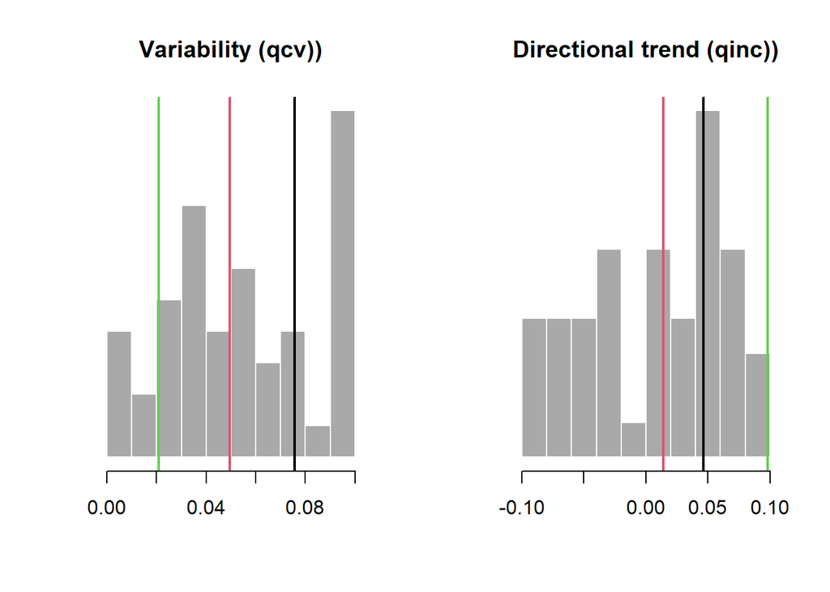

#### Time-Series

Time-series plot showing 3 trends in future fishing efficiency (catchability):

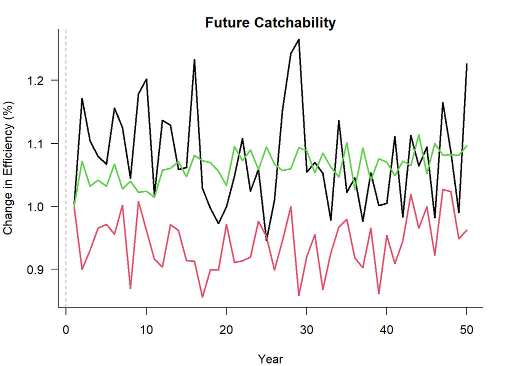

### Fishery gear length selectivity: L5, LFS, Vmaxlen, isRel

**L5**: Shortest length at which 5% of the population is vulnerable to selection by the gear used in this fleet. Values can either be specified as lengths (in the same units used for the maturity and growth parameters in the stock object) or as a percentage of the size of maturity (see the parameter isRel for more information). For each simulation a single value is drawn from a uniform distribution specified by the upper and lower bounds provided. This value is the same in all years unless cpars is used to provide time-varying selection.

Specified Value(s): 140, 160

One of the primary changes to the DLMtool after the demo phase of this project was the addition of parameters to specify a retention curve that is separate from the selectivity curve. This allows us to more accurately model any mortality associated with the discard of sublegal fish.

Depending on the type of hooks and baits used it is possible to catch barred sand bass that are much smaller than the legal size limit. The majority of these fish are released, though the available data suggests that some sublegals are retained each year. An ongoing Department study monitoring bass discard rates aboard CPFVs has recorded barred sand bass as small as 5 in (127 mm) being caught and released. We fit a logistic curve to RecFIN data that included both retained and discarded fish to determine the size at which fish can be caught by anglers. Based on this we estimated that fish first become vulnerable to hook and line gear between 140-160mm, and are fully vulnerable at 250-275mm. We assumed a logistic selectivity curve, and so the vulnerability at the maximum size was set to 1.

**LFS**: Shortest length at which 100% of the population is vulnerable to selection by the gear used by this fleet. Values can either be specified as lengths (in the same units used for the maturity and growth parameters in the stock object) or as a percentage of the size of maturity (see the parameter isRel for more information). For each simulation a single value is drawn from a uniform distribution specified by the upper and lower bounds provided. This value is the same in all years unless cpars is used to provide time-varying selection.

Specified Value(s): 250, 275

**Vmaxlen**: Proportion of fish selected by the gear at the asymptotic length (‘Stock@Linf’). Upper and Lower bounds between 0 and 1. A value of 1 indicates that 100% of fish are selected at the asymptotic length, and the selection curve is logistic. If Vmaxlen is less than 1 the selection curve is dome shaped. For example, if Vmaxlen is 0.4, then only 40% of fish are vulnerable to the fishing gear at the asymptotic length.

Specified Value(s): 1, 1

**isRel**: Specify whether selection and retention parameters use absolute lengths or relative to the size of maturity. Single logical value (TRUE or FALSE).

Specified Value(s): FALSE

### Fishery length retention: LR5, LFR, Rmaxlen, DR

**LR5**: Shortest length at which 5% of the population is vulnerable to retention by the fleet. Values can either be specified as lengths (in the same units used for the maturity and growth parameters in the stock object) or as a percentage of the size of maturity (see the parameter isRel for more information). For each simulation a single value is drawn from a uniform distribution specified by the upper and lower bounds provided. This value is the same in all years unless cpars is used to provide time-varying selection.

Specified Value(s): 0, 0

Refer to the last section of the introduction in this report for a description of how cpars were used to calculate retention.

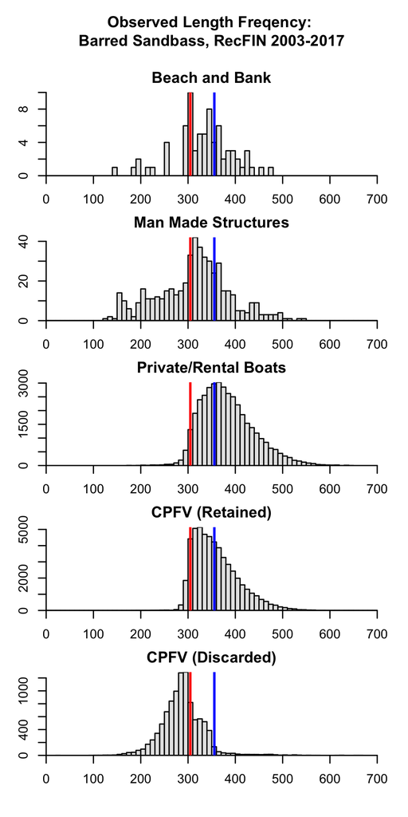

Length Frequencies for Barred Sand Bass, All Fleets

**LFR**: Shortest length where 100% of the population is vulnerable to retention by the fleet. Values can either be specified as lengths (in the same units used for the maturity and growth parameters in the stock object) or as a percentage of the size of maturity (see the parameter isRel for more information). For each simulation a single value is drawn from a uniform distribution specified by the upper and lower bounds provided. This value is the same in all years unless cpars is used to provide time-varying selection.

Specified Value(s): 0, 0

**Rmaxlen**: Proportion of fish retained at the asymptotic length (‘Stock@Linf’). Upper and Lower bounds between 0 and 1. A value of 1 indicates that 100% of fish are retained at the asymptotic length, and the selection curve is logistic. If Rmaxlen is less than 1 the retention curve is dome shaped. For example, if Rmaxlen is 0.4, then only 40% of fish at the asymptotic length are retained.

Specified Value(s): 1, 1

**DR**: Discard rate, defined as the proportion of fully selected fish that are discarded by the fleet. Upper and Lower bounds between 0 and 1, with a value of 1 indicates that 100% of selected fish are discarded. For each simulation a single value is drawn from a uniform distribution specified by the upper and lower bounds provided.

Specified Value(s): 0.05, 0.1

This parameter specifies the percent of legal fish that are discarded. Catch and release rates for barred sand bass may be as high as 55% according to CRFS data (Semmens and Parnell 2014), but it is likely that the majority of those released are sublegals. Based on the data there do appear to be some legal sized fish that are discarded. Discard rates were estimated from CRFS data on discarded vs. retained fish in the CPFV fleet each year between 2003 and 2017.

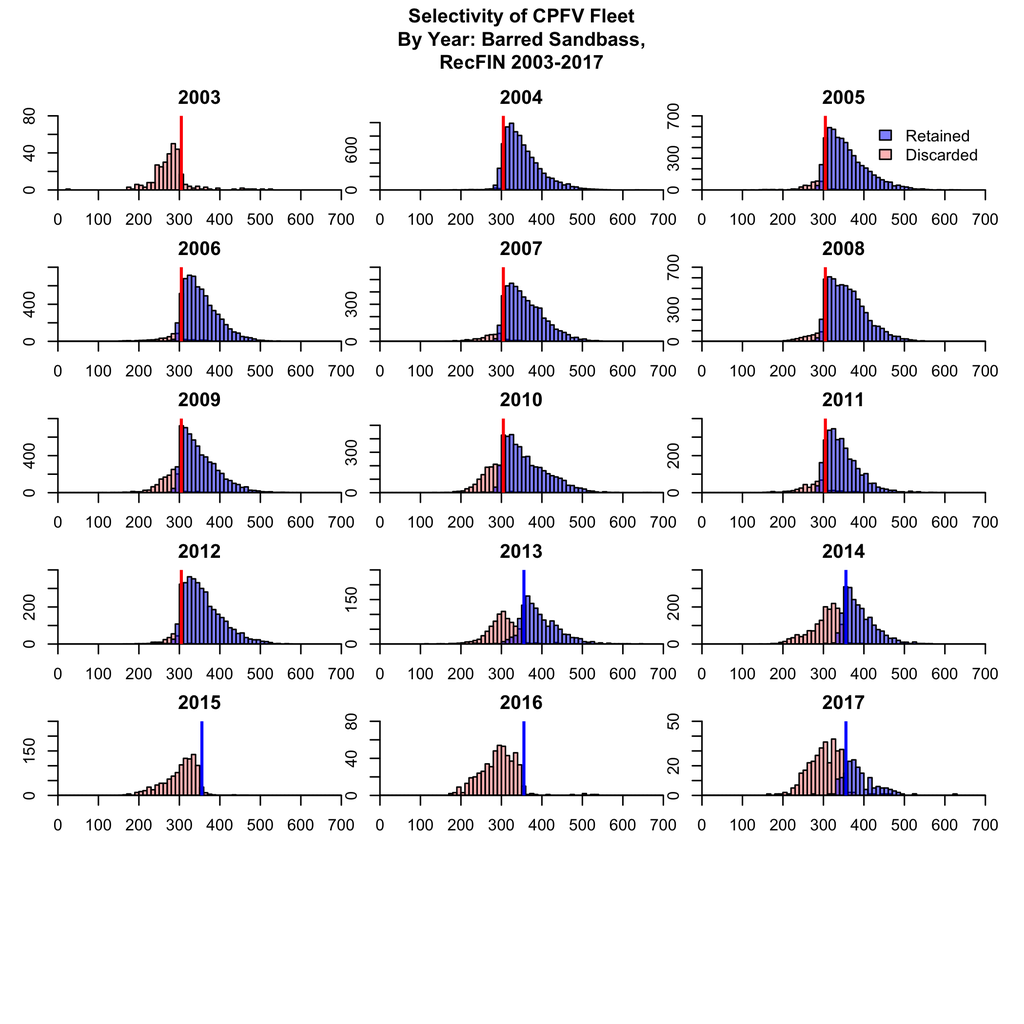

Selectivity of the CPFV Fleet for Barred Sand Bass by Year

### Current Year: CurrentYr

**CurrentYr**: The last historical year simulated before projections begin. Single value. Note that this should match the last historical year specified in the Data object, which is usually the last historical year for which data is available.

Specified Value(s): 2018

The most current year for which data is available is 2018.

### Existing Spatial Closures: MPA

**MPA**: Logical argument (TRUE or FALSE). Creates an MPA in Area 1 for all years if true is selected. Defaults to FALSE.

Specified Value(s): FALSE

California’s network of 133 MPAs contain a wide variety of habitats and depth ranges. However, the MPA network was not designed to specifically benefit a single species such as Barred Sand Bass, which are most abundant over inshore artificial and natural reefs, and spawn over soft bottom habitat. The significance of these MPAs is unclear as the majority of fishing pressure has historically focused on their spawning aggregations which are largely unprotected (Erisman and others 2011). As such, we did not model MPA protection for this species.

# Obs Parameters

The Observation Table contains the parameters that are used to generate the simulated fishery data within the MSE model. Except for exceptions noted below, the parameters used for the observation model were based on the values presented in Carruthers et al. (2014) and are found in the ‘Generic_obs’ observation object in the DLMtool except where information was found to suggest alternative values (see below).

### Catch statistics: Cobs, Cbiascv, CAA_nsamp, CAA_ESS, CAL_nsamp, CAL_ESS

**Cobs**: Observation error around the total catch. Observation error in the total catch is expressed as a coefficient of variation (CV). Cobs requires upper and lower bounds of a uniform distribution, and for each simulation a CV is sampled from this distribution. Each CV is used to specify a log-normal error distribution with a mean of 1 and a standard deviation equal to the sampled CV. The yearly observation error values for the catch data are then drawn from this distribution. For each time step the simulation model records the true catch, but the observed catch is generated by applying this yearly error term (plus any bias, if specified) to the true catch.

Specified Value(s): 0.1, 0.3

**Cbiascv**: Log-normally distributed coefficient of variation controlling the sampling bias in observed catch for each simulation. Bias occurs when catches are systematically skewed away from the true catch level (for example, due to underreporting of catch or undetected illegal catches). Cbiascv is a single value specifying the standard deviation of a log-normal distribution with a mean of 1 and a standard deviation equal to the sampled CV. For each simulation a bias value is drawn from this distribution, and that bias is applied across all years.

Specified Value(s): 0.1

**CAA_nsamp**: Number of catch-at-age observations collected per time step. For each time step a single value is drawn from a uniform distribution specified by the upper and lower bounds provided. Positive integers.

Specified Value(s): 2000, 3000

**CAA_ESS**: Effective sample size of catch-at-age observations collected per time step. For each time step a single value is drawn from a uniform distribution specified by the upper and lower bounds provided. CAA_ESS should not exceed CAA_nsamp. Positive integers.

Specified Value(s): 2000, 3000

**CAL_nsamp**: Number of catch-at-length observations collected per time step. For each time step a single value is drawn from a uniform distribution specified by the upper and lower bounds provided. Positive integers.

Specified Value(s): 2000, 3000

The number of length samples was modeled on the number of length samples collected yearly as part of RecFIN sampling between 2010 and 2018.

**CAL_ESS**: Effective sample size. For each time step a single value is drawn from a uniform distribution specified by the upper and lower bounds provided. CAL_ESS should not exceed CAL_nsamp. Positive integers.

Specified Value(s): 2000, 3000

It is assumed that the effective sample size is the same as the number of lengths sampled. This is because the sampled lengths come from a number of different sampling events targeting the different fishing modes at different locations and times of the year. As a result, each observed length is likely to be an independent observation.

### Index imprecision, bias and hyperstability: Iobs, Btobs, Btbiascv, beta

**Iobs**: Observation error in the relative abundance index expressed as a coefficient of variation (CV). Iobs requires upper and lower bounds of a uniform distribution, and for each simulation a CV is sampled from this distribution. Each CV is used to specify a log-normal error distribution with a mean of 1 and a standard deviation equal to the sampled CV. The yearly observation error values for the index of abundance data are then drawn from this distribution. For each time step the simulation model records the true change in abundance, but the observed index is generated by applying this yearly error term (plus any bias, if specified) to the true relative change in abundance. Positive real numbers.

Specified Value(s): 0.1, 0.4

**Btobs**: Observation error in the absolute abundance expressed as a coefficient of variation (CV). Btobs requires upper and lower bounds of a uniform distribution, and for each simulation a CV is sampled from this distribution. Each CV is used to specify a log-normal error distribution with a mean of 1 and a standard deviation equal to the sampled CV. The yearly observation error values for the absolute abundance data are then drawn from this distribution. For each time step the simulation model records the true abundance, but the observed abundance is generated by applying this yearly error term (plus any bias, if specified) to the true abundance. Positive real numbers.

Specified Value(s): 0.33, 3

**Btbiascv**: Log-normally distributed coefficient (CV) controlling error in observations of the current stock biomass. Bias occurs when the observed index of abundance is is systematically higher or lower than the true relative abundance. Btbiascv is a single value specifying the standard deviation of a log-normal distribution with a mean of 1 and a standard deviation equal to the sampled CV. For each simulation a bias value is drawn from this distribution, and that bias is applied across all years. Positive real numbers.

Specified Value(s): 0.2

**beta**: A parameter controlling hyperstability/hyperdepletion in the measurement of abundance. For each simulation a single value is drawn from a uniform distribution specified by the upper and lower bounds provided. Values below 1 lead to hyperstability (the observed index decreases more slowly than the true abundance) and values above 1 lead to hyperdepletion (the observed index decreases more rapidly than true abundance). Positive real numbers.

Specified Value(s): 0.45, 1

### Bias in maturity, natural mortality rate and growth parameters: LenMbiascv, Mbiascv, Kbiascv,t0biascv, Linfbiascv

**LenMbiascv**: Log-normal coefficient of variation for sampling bias in observed length at 50 percent maturity. LenMbiascv is a single value specifying the standard deviation of a log-normal distribution with a mean of 1 and a standard deviation equal to the sampled CV. For each simulation a bias value is drawn from this distribution, and that bias is applied across all years. Positive real numbers.

Specified Value(s): 0.1

**Mbiascv**: Log-normal coefficient of variation for sampling bias in observed natural mortality rate. Uniform distribution lower and upper bounds. Mbiascv is a single value specifying the standard deviation of a log-normal distribution with a mean of 1 and a standard deviation equal to the sampled CV. For each simulation a bias value is drawn from this distribution, and that bias is applied across all years. Positive real numbers.

Specified Value(s): 0.05

**Kbiascv**: Log-normal coefficient of variation for sampling bias in observed growth parameter K. Kbiascv is a single value specifying the standard deviation of a log-normal distribution with a mean of 1 and a standard deviation equal to the sampled CV. For each simulation a bias value is drawn from this distribution, and that bias is applied across all years. Positive real numbers.

Specified Value(s): 0.05

**t0biascv**: Log-normal coefficient of variation for sampling bias in observed t0. t0biascv is a single value specifying the standard deviation of a log-normal distribution with a mean of 1 and a standard deviation equal to the sampled CV. For each simulation a bias value is drawn from this distribution, and that bias is applied across all years. Positive real numbers.

Specified Value(s): 0.05

**Linfbiascv**: Log-normal coefficient of variation for sampling bias in observed maximum length. Linfbiascv is a single value specifying the standard deviation of a log-normal distribution with a mean of 1 and a standard deviation equal to the sampled CV. For each simulation a bias value is drawn from this distribution, and that bias is applied across all years. Positive real numbers.

Specified Value(s): 0.05

### Bias in length at first capture, length at full selection: LFCbiascv, LFSbiascv

**LFCbiascv**: Log-normal coefficient of variation for sampling bias in observed length at first capture. LFCbiascv is a single value specifying the standard deviation of a log-normal distribution with a mean of 1 and a standard deviation equal to the sampled CV. For each simulation a bias value is drawn from this distribution, and that bias is applied across all years. Positive real numbers.

Specified Value(s): 0.05

**LFSbiascv**: Log-normal coefficient of variation for sampling bias in length-at-full selection. LFSbiascv is a single value specifying the standard deviation of a log-normal distribution with a mean of 1 and a standard deviation equal to the sampled CV. For each simulation a bias value is drawn from this distribution, and that bias is applied across all years. Positive real numbers.

Specified Value(s): 0.05

### Bias in fishery reference points, unfished biomass, FMSY, FMSY/M ratio, biomass at MSY relative to unfished: FMSY_Mbiascv, BMSY_B0biascv

**FMSY_Mbiascv**: Log-normal coefficient of variation for sampling bias in estimates of the ratio of the fishing mortality rate that gives the maximum sustainable yield relative to the assumed instantaneous natural mortality rate. FMSY/M. FMSY_Mbiascv is a single value specifying the standard deviation of a log-normal distribution with a mean of 1 and a standard deviation equal to the sampled CV. For each simulation a bias value is drawn from this distribution, and that bias is applied across all years. Positive real numbers.

Specified Value(s): 0.2

**BMSY_B0biascv**: Log-normal coefficient of variation for sampling bias in estimates of the BMSY relative to unfished biomass (BMSY/B0). BMSY_B0biascv is a single value specifying the standard deviation of a log-normal distribution with a mean of 1 and a standard deviation equal to the sampled CV. For each simulation a bias value is drawn from this distribution, and that bias is applied across all years. Positive real numbers.

Specified Value(s): 0.2

### Management targets in terms of the index (i.e., model free), the total annual catches and absolute biomass levels: Irefbiascv, Crefbiascv, Brefbiascv

**Irefbiascv**: Log-normal coefficient of variation for sampling bias in the observed relative index of abundance (Iref). Irefbiascv is a single value specifying the standard deviation of a log-normal distribution with a mean of 1 and a standard deviation equal to the sampled CV. For each simulation a bias value is drawn from this distribution, and that bias is applied across all years. Positive real numbers.

Specified Value(s): 0.2

**Crefbiascv**: Log-normal coefficient of variation for sampling bias in the observed reference catch (Cref). Crefbiascv is a single value specifying the standard deviation of a log-normal distribution with a mean of 1 and a standard deviation equal to the sampled CV. For each simulation a bias value is drawn from this distribution, and that bias is applied across all years. Positive real numbers.

Specified Value(s): 0.2

**Brefbiascv**: Log-normal coefficient of variation for sampling bias in the observed reference biomass (Bref). Brefbiascv is a single value specifying the standard deviation of a log-normal distribution with a mean of 1 and a standard deviation equal to the sampled CV. For each simulation a bias value is drawn from this distribution, and that bias is applied across all years. Positive real numbers.

Specified Value(s): 0.5

### Depletion bias and imprecision: Dbiascv, Dobs

**Dbiascv**: Log-normal coefficient of variation for sampling bias in the observed depletion level. Dbiascv is a single value specifying the standard deviation of a log-normal distribution with a mean of 1 and a standard deviation equal to the sampled CV. For each simulation a bias value is drawn from this distribution, and that bias is applied across all years. Positive real numbers.

Specified Value(s): 0.5

**Dobs**: Log-normal coefficient of variation controlling error in observations of stock depletion among years. Observation error in the depletion expressed as a coefficient of variation (CV). Dobs requires the upper and lower bounds of a uniform distribution, and for each simulation a CV is sampled from this distribution. Each CV is used to specify a log-normal error distribution with a mean of 1 and a standard deviation equal to the sampled CV. The yearly observation error values for the depletion data are then drawn from this distribution. For each time step the simulation model records the true depletion, but the observed depletion is generated by applying this yearly error term (plus any bias, if specified) to the true depletion.

Specified Value(s): 0.05, 0.1

### Recruitment compensation and trend: hbiascv, Recbiascv, sigmaRbiascv

**hbiascv**: Log-normal coefficient of variation for sampling persistent bias in steepness. hbiascv is a single value specifying the standard deviation of a log-normal distribution with a mean of 1 and a standard deviation equal to the sampled CV. For each simulation a bias value is drawn from this distribution, and that bias is applied across all years. Positive real numbers.

Specified Value(s): 0.2

**Recbiascv**: Log-normal coefficient of variation for sampling persistent bias in recent recruitment strength. Recbiascv requires the upper and lower bounds of a uniform distribution, and for each simulation a CV is sampled from this distribution. Each CV is used to specify a log-normal error distribution with a mean of 1 and a standard deviation equal to the sampled CV. The yearly bias values for the depletion data are then drawn from this distribution. Positive real numbers.

Specified Value(s): 0.1, 0.3

**sigmaRbiascv**: Log-normal coefficient of variation for sampling persistent bias in recruitment variability. sigmaRbiascv is a single value specifying the standard deviation of a log-normal distribution with a mean of 1 and a standard deviation equal to the sampled CV. For each simulation a bias value is drawn from this distribution, and that bias is applied across all years. Positive real numbers.

Specified Value(s): 0.1

No justification provided.

### Effort: Eobs, Ebiascv

**Eobs**: Observation error around the total effort. Observation error in the total effort is expressed as a coefficient of variation (CV). Eobs requires upper and lower bounds of a uniform distribution, and for each simulation a CV is sampled from this distribution. Each CV is used to specify a log-normal error distribution with a mean of 1 and a standard deviation equal to the sampled CV. The yearly observation error values for the effort data are then drawn from this distribution. For each time step the simulation model records the true effort, but the observed effort is generated by applying this yearly error term (plus any bias, if specified) to the true effort.

Specified Value(s): 0, 0

No justification provided.

**Ebiascv**: Log-normally distributed coefficient of variation controlling the sampling bias in observed effort for each simulation. Bias occurs when effort is systematically skewed away from the true effort level. Ebiascv is a single value specifying the standard deviation of a log-normal distribution with a mean of 1 and a standard deviation equal to the sampled CV. For each simulation a bias value is drawn from this distribution, and that bias is applied across all years.

Specified Value(s): 0

No justification provided.

## Observation Parameters

### Catch Observations

#### Sampled Parameters

Histograms of 48 simulations of inter-annual variability in catch observations (`Csd`) and persistent bias in observed catch (`Cbias`), with vertical colored lines indicating 3 randomly drawn values used in other plots:

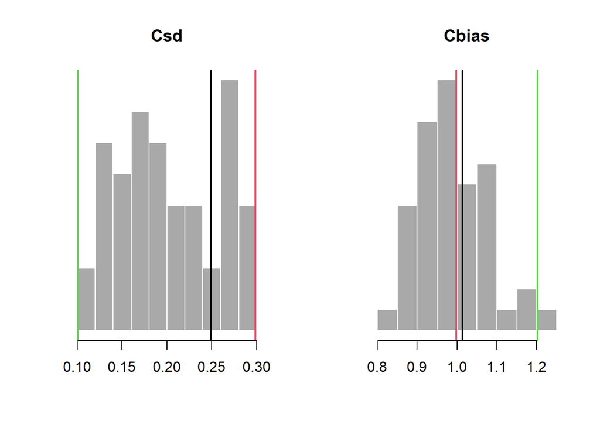

#### Time-Series

Time-series plots of catch observation error for historical and projection years:

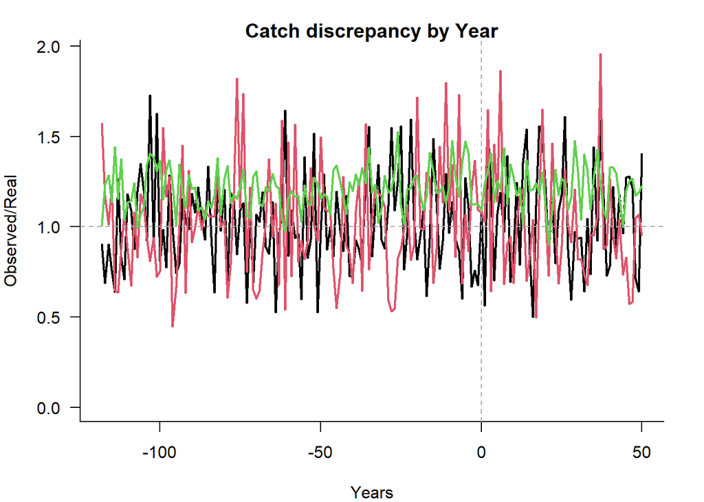

### Depletion Observations

#### Sampled Parameters

Histograms of 48 simulations of inter-annual variability in depletion observations (`Dobs`) and persistent bias in observed depletion (`Dbias`), with vertical colored lines indicating 3 randomly drawn values used in other plots:

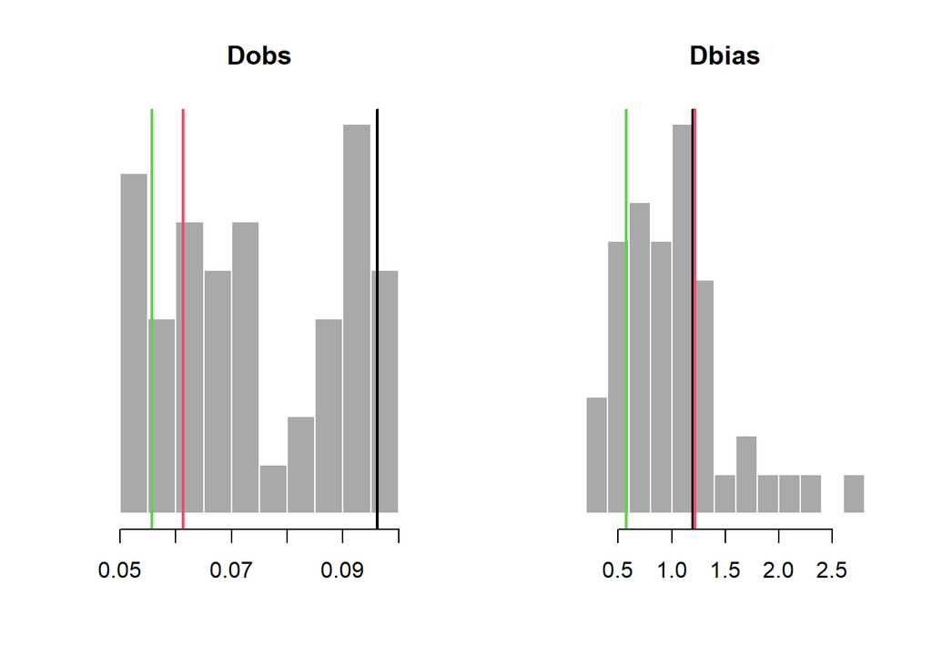

#### Time-Series

Time-series plots of depletion observation error for historical and projection years:

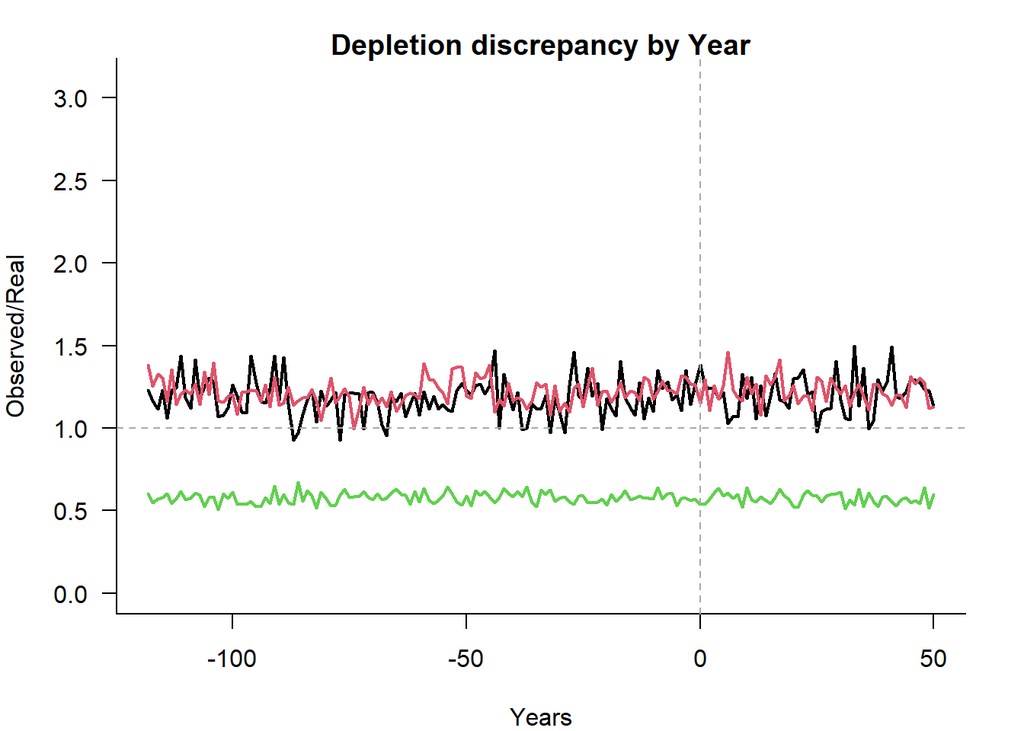

### Abundance Observations

#### Sampled Parameters

Histograms of 48 simulations of inter-annual variability in abundance observations (`Btobs`) and persistent bias in observed abundance (`Btbias`), with vertical colored lines indicating 3 randomly drawn values used in other plots:

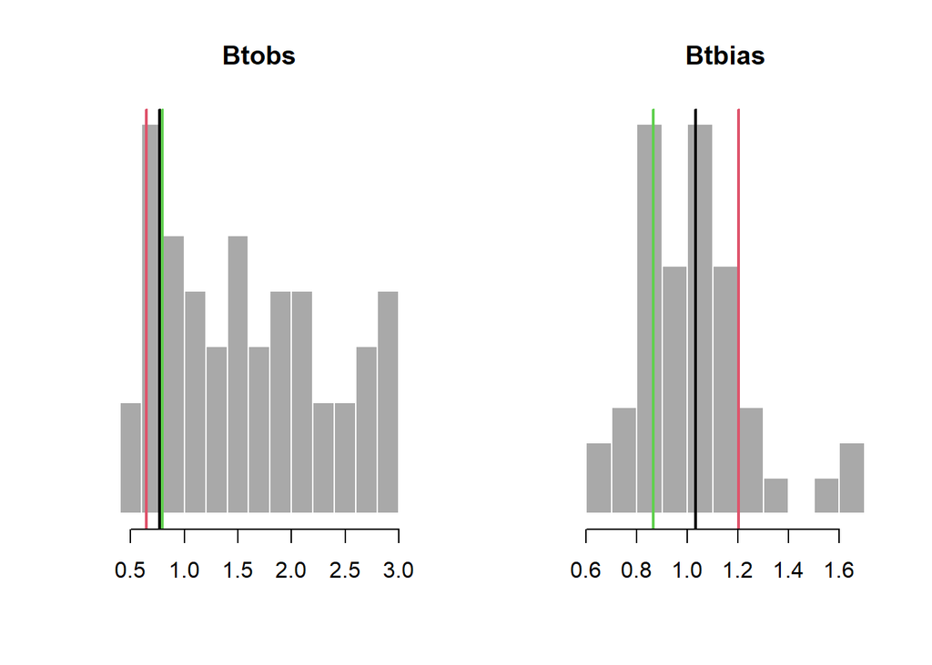

#### Time-Series

Time-series plots of abundance observation error for historical and projection years:

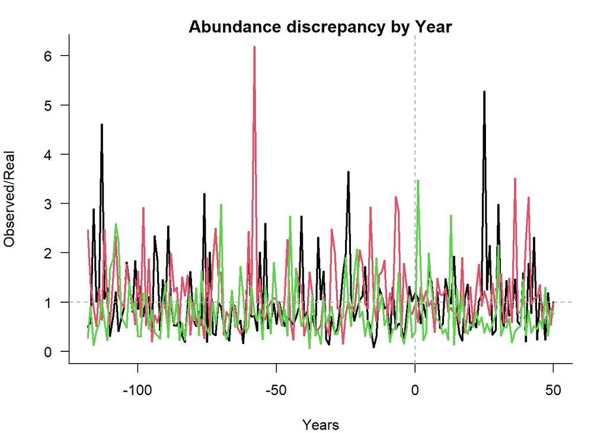

### Index Observations

#### Sampled Parameters

Histograms of 48 simulations of inter-annual variability in index observations (`Iobs`) and hyper-stability/depletion in observed index (`beta`), with vertical colored lines indicating 3 randomly drawn values used in other plots:

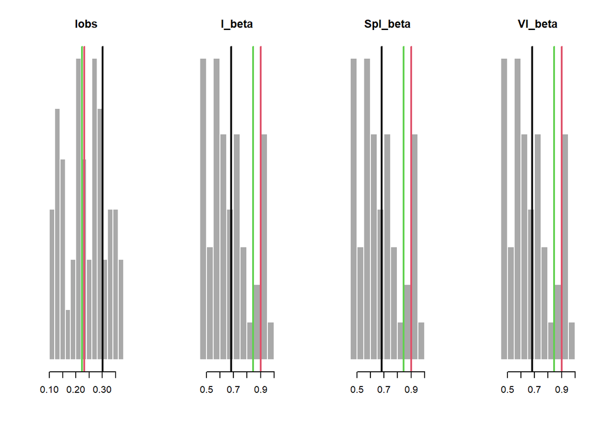

#### Time-Series

Time-series plot of 3 samples of index observation error:

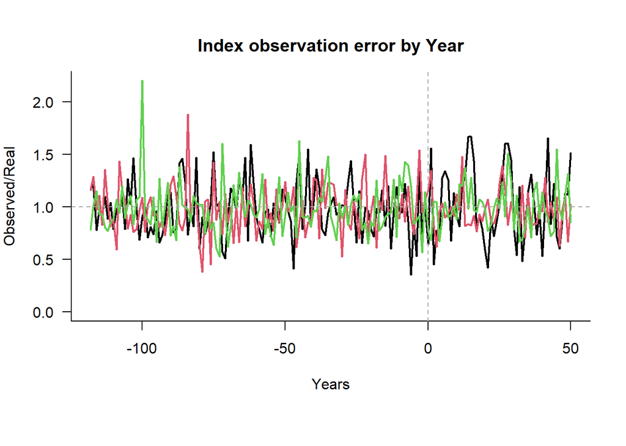

Plot showing an example true abundance index (blue) with 3 samples of index observation error and the hyper-stability/depletion parameter (`beta`):

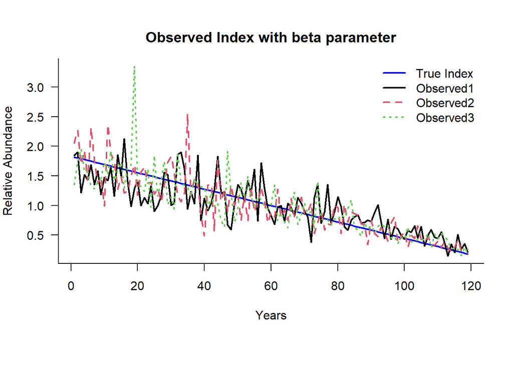